# FARMR!SK automatic report

Farm: bl3_v3

Published

Last Updated on Monday 17 November, 2025 (14:32:11)

**User ID:** trucha **Farm ID:** bl3_v3 **Survey date:** 2024-10-08

# **Risk analysis results**

> *All risk values from Monte Carlo simulations are provided as median (50th percentile) with 95% confidence interval (97.5%–2.5%).*

The annual probability of disease entry is **0.913%** (0.385-1.75%) for infectious bovine rhinotracheitis (IBR), **1.14%** (0.423-2.45%) for bovine viral diarrhea (BVD) and **0.000703%** (0.000115-0.00346%) for tuberculosis (TB).

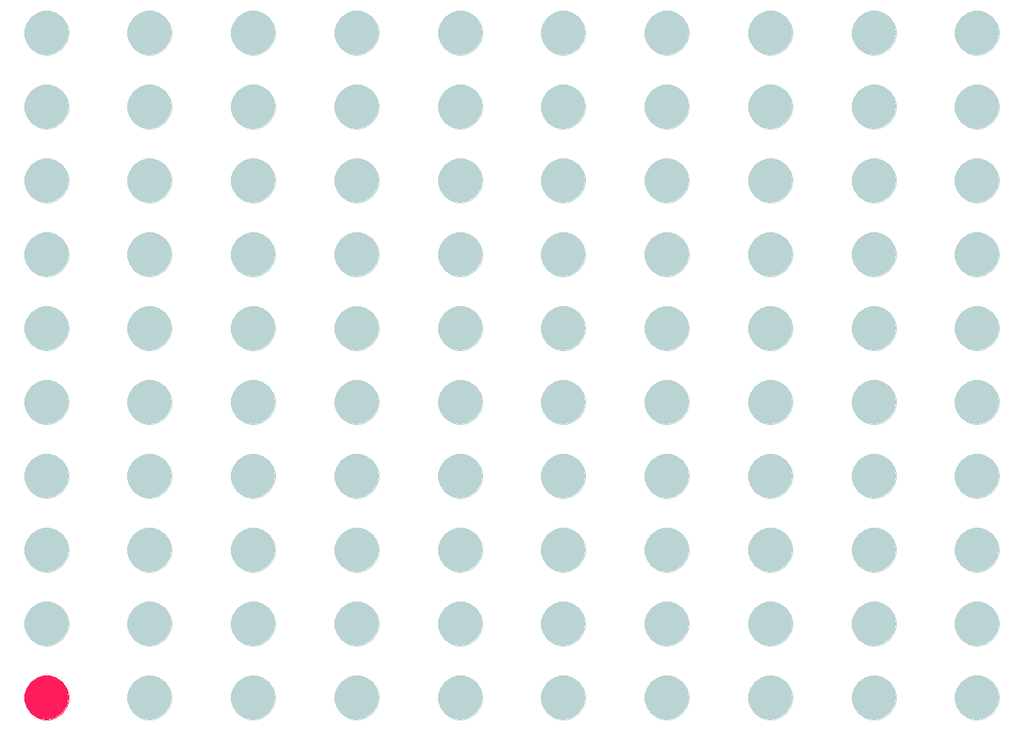

(a) IBR

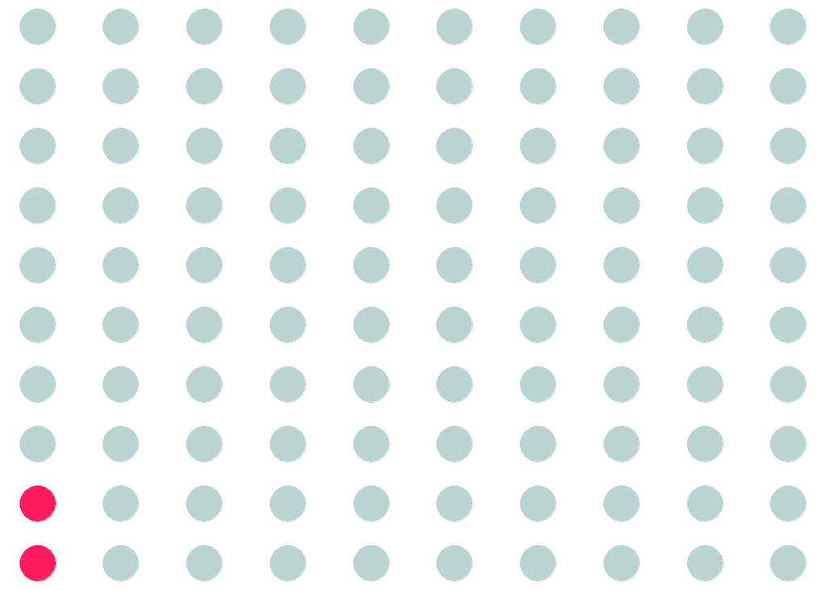

(b) BVD

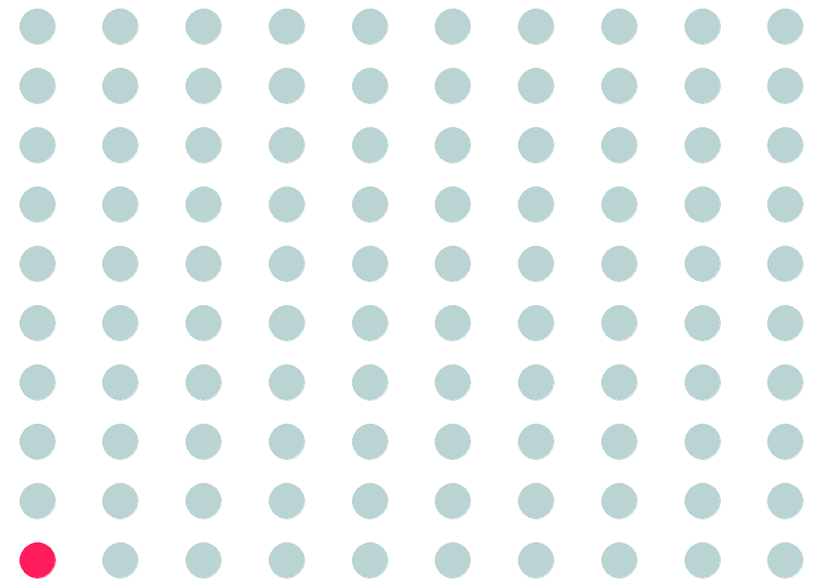

(c) TB

Figure 1.1: Risk of disease entry

The main pathways of disease entry are: **Vehicle visits to the farm** and **People visits to the farm**.

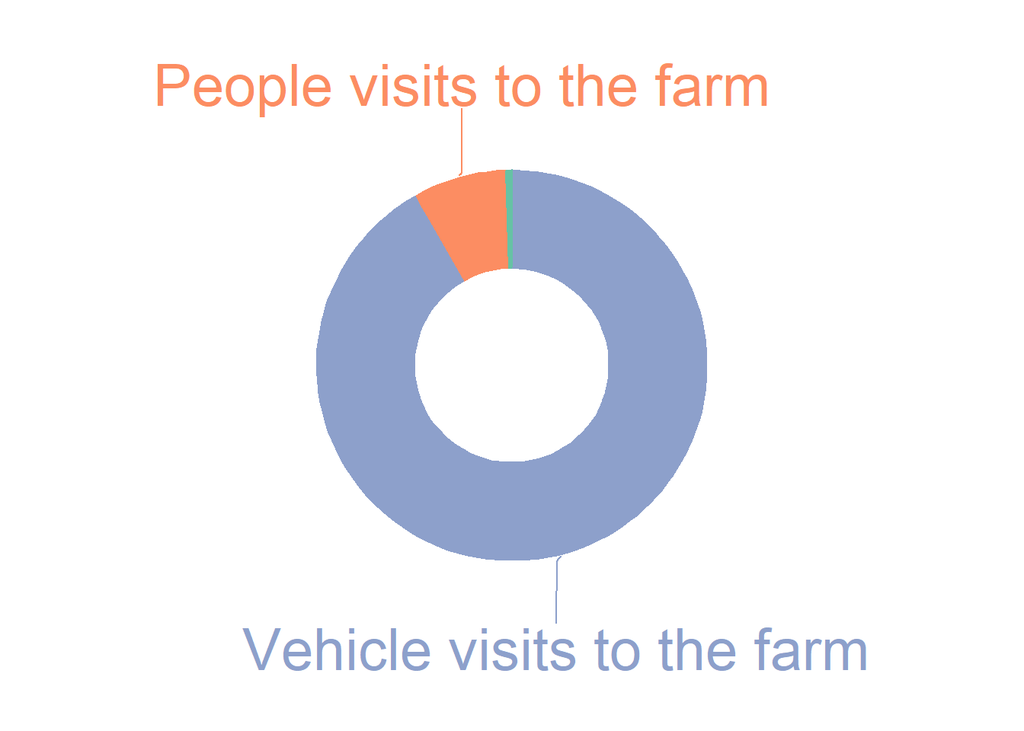

(a) IBR

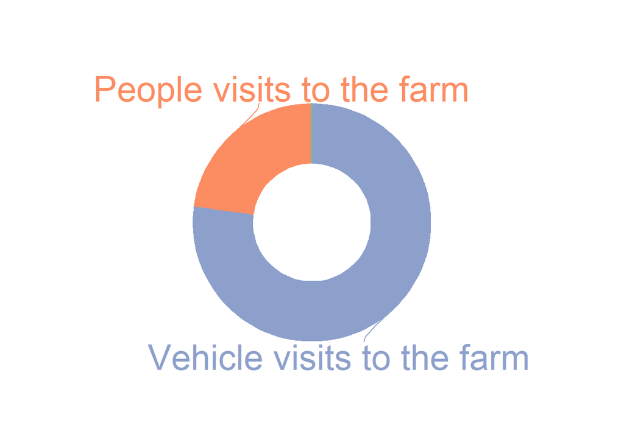

(b) BVD

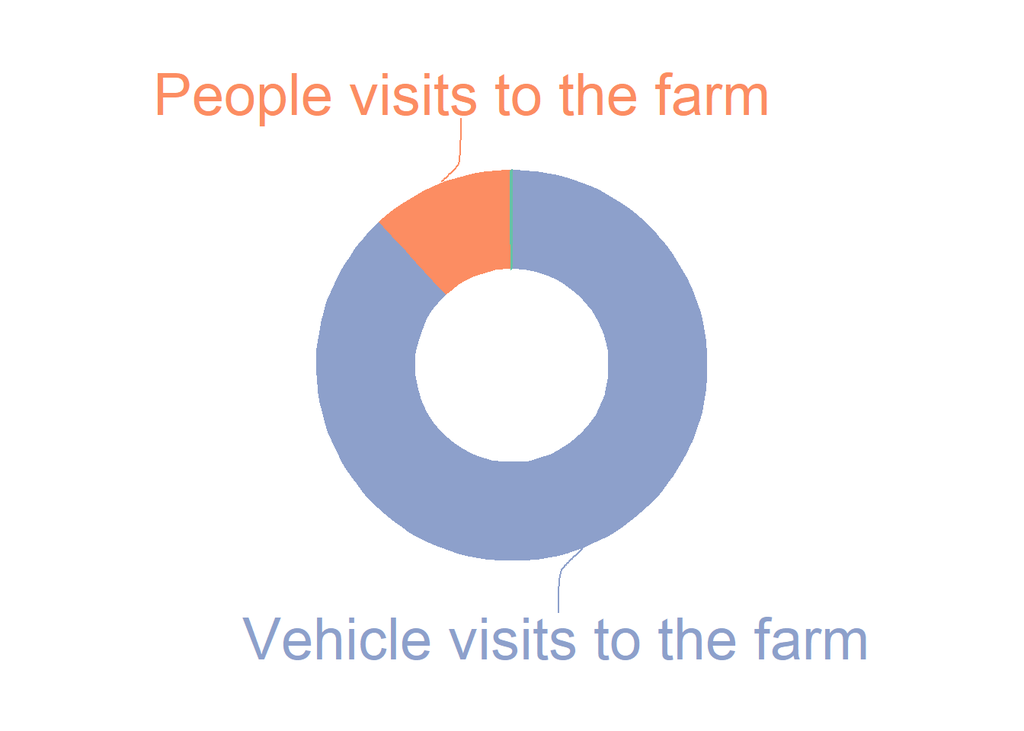

(c) TB

Figure 1.2: Risk of disease entry by pathway

## **Infectious Bovine Rhinotracheitis (IBR)**

### Current risk

Annual risk of IBR entry in the farm: **0.913%** (0.385-1.75%)

By pathway:

- Vehicle visits to the farm: **0.836%** (0.303-1.65%)
- People visits to the farm: **0.0703%** (0.0192-0.163%)
- Neigbouring farms: **0.00431%** (0.000219-0.0137%)

### Risk reduction of biosecurity measures

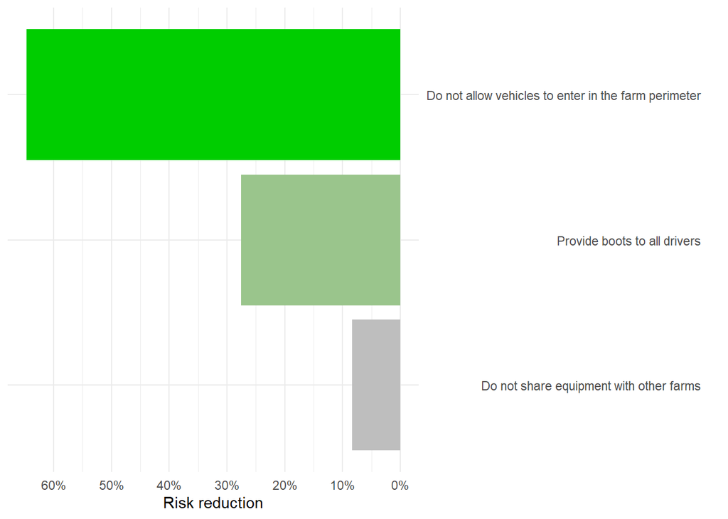

## **Bovine viral diarrhea (BVD)**

### Current risk

Annual risk of BVD entry in the farm: **1.14%** (0.423-2.45%)

By pathway:

- Vehicle visits to the farm: **0.839%** (0.225-2.05%)
- People visits to the farm: **0.247%** (0.0606-0.838%)
- Neigbouring farms: **1.81e-10%** (4.11e-13-2.47e-09%)

### Risk reduction of biosecurity measures

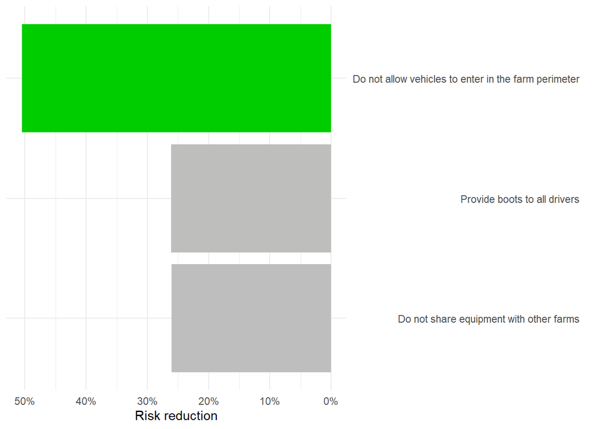

## **Bovine Tuberculosis (TB)**

### Current risk

Annual risk of TB entry in the farm: **0.000703%** (0.000115-0.00346%)

By pathway:

- Vehicle visits to the farm: **0.000555%** (4.89e-05-0.00329%)
- People visits to the farm: **7.38e-05%** (5.72e-06-0.000563%)
- Neigbouring farms: **6.37e-07%** (3.1e-10-1.81e-05%)

### Risk reduction of biosecurity measures

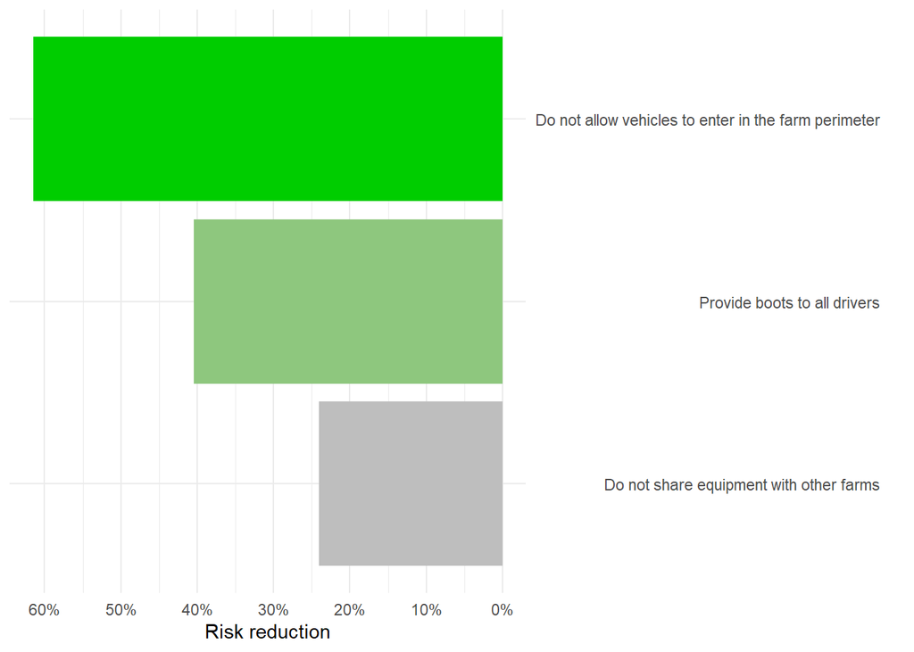

# 🐄 Description of the farm

## Farm information

**Location:** Cataluña, Spain

**Farm type:** Dairy cattle, NA

**Cattle cens:**

- 10 Calves ( <8 m)
- 100 Heifers (8 - 24 m)
- 190 Adult cows (>24 m)
- 0 Bulls

**Other animals in the farm:**

- **Direct contact with cattle:** 2 cats, 4 ocas
- **No direct contact with cattle:** 10 poultry

**Neighbours**: 1 cattle farms within a 1-2km radious, no direct contact (IBR: 0.00431%, BVD: 1.81e-10%, TB: 6.37e-07%)

## Farm vehicles

*The farm does not have its own vehicles for animal transport.*

## Visits

### People entering the barn

| Visit | Type | Frequency | Boots | Equipment | Risk |
| --- | --- | --- | --- | --- | --- |
| Veterinari reproucció | External veterinarians | 100 | Never used in other farms | Always used in other farms, always cleaned and disinfected | IBR: 0.0582%, BVD: 0.205%, TB: 5.2e-05% |
| Podòleg | Other animal professionals (e.g. hoof trimmer) | 12 | Never used in other farms | Always used in other farms, always cleaned and disinfected | IBR: 0.00952%, BVD: 0.035%, TB: 8.33e-06% |
| Veterinari sanejament | External veterinarians | 2 | Never used in other farms | Always used in other farms, always cleaned and disinfected | IBR: 0.00114%, BVD: 0.00398%, TB: 1.05e-06% |

### Vehicles entering the farm perimeter

| Visit | Type | Frequency | Driver | Risk |
| --- | --- | --- | --- | --- |
| Escorxador vaques | Slaughterhouse vehicle | 12 | Enters areas used by farm animals (no contact with animals), boots always used in other farms, unk cleaned and disinfected | IBR: 0.384%, BVD: 0.086%, TB: 0.000279% |
| Vedells Engreix | Calf transport vehicle | 24 | Enters areas used by farm animals (no contact with animals), boots always used in other farms, unk cleaned and disinfected | IBR: 0.352%, BVD: 0.713%, TB: 0.000106% |
| Llet | Milk collection vehicle | 180 | - | IBR: 0.0284%, BVD: 0.00619%, TB: 1.9e-06% |
| Pinso | Feed vehicle | 20 | - | IBR: 0.00477%, BVD: 0.00101%, TB: 3.37e-07% |
| Cadávers | Rendering vehicle | 10 | - | IBR: 0.0035%, BVD: 0.000641%, TB: 2.03e-07% |
| Camió dels fems | Rendering vehicle | 10 | - | IBR: 0.00318%, BVD: 0.000602%, TB: 2.05e-07% |

# 🚚 Movements

Animal movements in the last 12 months

*No movements in selected period*

### Health status and tests in origin

### Quarantine

#### Characteristics

*No quarantine*

# 🐗 Wildlife

**Wildlife:** negligible risk

- Outdoors grazing: No outdoors grazing (negligible risk)
- Pasture (trashumance): No pastures

### Farm water points

*No outdoors water points*

### Pasture water points

*No pasture water points*

# Comments

*No survey comments*

# Technical Annex